###### Virtualisation et Cloud - TEK-UP University

# LAB05 : Docker- Partie3

###### Durée conseillée : 3h

### Objectif

- L’objectif de ce TP est de créer une application Docker Web basique qui affiche un message d'accueil.

###### Prérequis

- Système Linux Ubuntu avec Docker installé.

###### Démarche

- Etape 1 : Création d'une application Web sur la machine locale
- Etape 2 : Création de l'application Docker
- Etape 3 : Démarrage application et gestion conteneur

## Création d'une application Web sur la machine locale

### Installation de HTTPD - serveur web Apache2

Apache est le serveur Web le plus couramment utilisé sur les systèmes Linux.

1- Installez Apache :

```python
$ sudo apt update
$ sudo apt install apache2
```

2- Vérifiez que le service est bien installé

```python
$ sudo systemctl status apache2
```

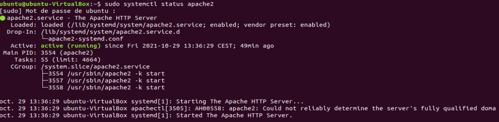

3- Ouvrez votre navigateur sur l'adresse: http://localhost et vérifiez la page d'accueil Apache

[figure not shown]

### Configuration du serveur Web

1- Arretez le service apache2

```python
$ sudo systemctl stop apache2
```

2- Démarrez de nouveau apache2, en avant plan (foreground), en utilisant la comande suivante :

```python
$ sudo apachectl -D FOREGROUND
```

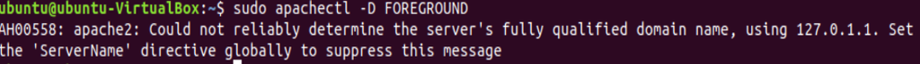

3- Arretez de nouveau apache2

```python
$ sudo systemctl stop apache2
```

```python
$ sudo nano /etc/apache2/apache2.conf
```

- Ajoutez en fin de fichier la ligne suivante :

```python
servername hostname
```

5- Démarrez apache2 en avant plan

```python
$ sudo apache2ctl -D FOREGROUND
```

### Création de fichier de l'application

```python
$ sudo mkdir /var/www/html/webserver_project
```

2- Créez et éditez le fichier "index.html" qui va définir le message d'accueil de votre page Web en ajoutant le texte ci-dessous :

```python
$ sudo nano index.html
```

```python
 <!DOCTYPE html>
<html>
 <body><h1>
        Hello TEK-UP : Welcome to Docker Lab
    </h1></body>
</html>
```

### Accès Application

1- Pour faire l'accès à votre application, ouvrez votre navigateur sur l'adresse : http://localhost/webserver_project

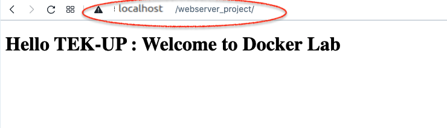

## Création de l'application Web Docker

### Suppression de l'application locale

1- Avant de tarvailler avec les conteneur Docker, déplacez le dossier de votre application sur votre répertoire maison.

- Ce dossier sera utilisé pour créer l'application Docker

```python
$ sudo mv /var/www/html/webserver_project /home/$USER
```

2- Désinstallez apache2

```python
$ sudo apt remove apache2
```

### Création du fichier image Dockerfile

1- Sous votre répertoire application (webserver_project), créez et éditez le fichier Dockerfile qui est la base de la création de l’image Docker :

```python
$ cd ~/webserver_project
```

```python
$ nano Dockerfile
```

- Contenu du Dockerfile

```python
FROM ubuntu:latest
# Update the list of packages
RUN apt-get -y update
#The following ARG turns off the questions normally asked for location and timezone for Apache
ARG DEBIAN_FRONTEND=noninteractive
# Install Apache
RUN apt-get install apache2 -y
# Configuration
RUN   echo "servername hostname" >> /etc/apache2/apache2.conf
# Define the working directory
WORKDIR /var/www/html/webserver_project
COPY index.html .
# Application Port
EXPOSE 80
CMD ["apachectl", "-D", "FOREGROUND"]
```

**Explication**

**- FROM ubuntu:latest** : Définit l'image de base : on va utiliser la dernière version de ubuntu:latest disponible sur Docker Hub

**- RUN apt update** : Met à jour de la liste des paquetages

**- ARG DEBIAN_FRONTEND=noninteractive** : Désactive le mode normal interactif de Apache (sélection de la Région et Time Zone)

**- RUN apt-get install apache2 -y** : Installe apache2

**- RUN echo "servername hostname" >> /etc/apache2/apache2.conf** : Ajoute la ligne "servername hostname" au fichier de configuration apache2.conf

**- WORKDIR /var/www/html/webserver_project** : Crée un répertoire de travail sur le système de fichiers de l'image

**- EXPOSE 80** : informe Docker que le conteneur est joignable sur le port spécifié.

**- CMD ["apachectl", "-D", "FOREGROUND"]** : précise à Docker Deamon la commande à exécuter pour lancer l'application.

### Création de l'image "webserver"

1- Créez l'image de l'application avec la commande "docker build"

- Le point (.) en fin indique le chemin de l'image (le dossier courant)

```python
$ docker build -t webserver .
```

2- Vérifiez que l'image existe dans le dépôt local

```python
$ docker images
```

```python
#Résultat
$ docker images
REPOSITORY   TAG       IMAGE ID       CREATED       SIZE
webserver    latest    f9dcf322bcff   4 hours ago   217MB
ubuntu       latest    ba6acccedd29   13 days ago   72.8MB
```

### Création et démarage conteneur image webserver

1- Démarrez un nouveau conteneur, nommée "webcontainer1", basé sur l'image "webserver"

```python
$ docker run --name webcontainer1 webserver
```

- Une fois démarré, le conteneur s'exécute en premier plan sur le terminal.
- Pour vérifier le fonctionnement de l'application web et consulter sa page d'accueil, on doit consulter le navigateur web sur l'adresse du conteneur et le port de l'application.

2- Pour déterminer l'adresse IP du conteneur, ouvrez un nouvel terminal et exécutez la commande suivante pour repérer l'adresse IP du conteneur :

```python
$ docker inspect  webcontainer1 | grep IP
```

```python
# Résultat
 docker inspect webcontainer1 | grep IP
            "LinkLocalIPv6Address": "",
            "LinkLocalIPv6PrefixLen": 0,
            "SecondaryIPAddresses": null,
            "SecondaryIPv6Addresses": null,
            "GlobalIPv6Address": "",
            "GlobalIPv6PrefixLen": 0,
            "IPAddress": "172.17.0.2",
            "IPPrefixLen": 16,
            "IPv6Gateway": "",
                    "IPAMConfig": null,
                    "IPAddress": "172.17.0.2",
                    "IPPrefixLen": 16,
                    "IPv6Gateway": "",
                    "GlobalIPv6Address": "",
                    "GlobalIPv6PrefixLen": 0,
```

- D'après le résultat de la commande ici, l'adresse du conteneur est 172.17.0.2

3- Consultez votre navigateur à l'adresse spécifiée

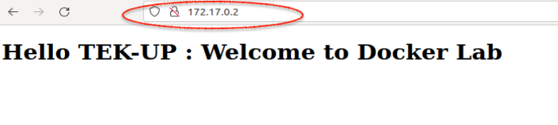

4- Arretez le conteneur webcontainer1.

```python
$ docker stop webcontainer
```

### Accès à l'application Docker depuis la machine hôte

#### Méthode 1 : port mapping

- Pour faire l'accès à l'application conteneurisée sur la machine hôte, on va faire le mapping entre port conteneur et port machine hôte.

```
- L'option " -p 3000:80" permet de relayer le flux du port conteneur 80 au port hôte 3000.
- L'option "-d" permet d'exécuter le conteneur en arrière plan.
```

```python
$ docker run -d -p 3000:80 --name webcontainer2 webserver
```

2- Pour faire l'accès à l'application, consultez l'adresse "localhost:3000" sur votre navigateur.

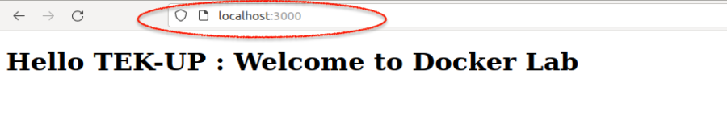

#### Méthode 2 : option "network"

1- Démarrez, en arrière plan, un conteneur nommé "webcontainer3" avec l'option" --network=host"

```python
$ docker run -d --network=host --name webcontainer3 websever
```

2- Pour faire l'accès à l'application, consultez l'adresse "localhost:80" sur votre navigateur.

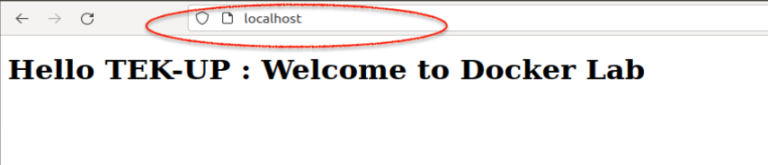